# Lab4_t-test

#### 4.3 Two-sample t-test

The two-sample t-test compares whether the means of two groups are significantly different form each other. This test has the following assumptions:

1. Assumes that the observations from *each group* represent a *random sample* from the population.
2. Assumes that the observations follow a *normal distribution*.
3. Assumes that the observations from the two groups have *the same variance*.

If we have two groups called group 1 and group 2, the two-sided hypothes for the two-sample t-test are:

$H_0 : \mu_1 = \mu_2$  
$H_A : \mu_1 \neq \mu_2$

Before we can test these hypotheses we need to ensure that our assumptions are met. You can test the normality assumption using any of the procedures that you already know (e.g. qqplots or the Shapiro Wilk statistic). To test the homogeneity (equal) of variance assumption we will use something called *Levene’s Test*. The *null hypothesis* of the Levene’s test is that the variance between the two groups are equal. The *alternative hypothesis* is that they are not equal.  
If we fail to reject the *null hypothesis* of the Levene’s test we can pool our variances and use a standard two-sample t-test. We would compute this t statistic using the following equations:

$SE_{\bar Y_1 - \bar Y_2} = \sqrt{s^2_p(\frac{1}{n_1}+\frac{1}{n_2})}$

where

$s^2_p = \frac{df_1s^2_1+df_2s^2_2}{df_1+df_2}$

is the pooled sample variance (described in your book). With these equations we can calculate the t statistic:

$t = \frac{\bar Y_1 - \bar Y_2}{SE_{\bar Y_1 - \bar Y_2}}$

where this t statistic has a df of $n_1 + n_2 - 2$.

If we reject the *null hypothesis* of the Levene’s test we use something called *Welch’s t-test*. We calculate the t statistic with a similar equation as equation 7, but the denominator is changed to account for the different variances between the two groups. Moreover, the df is also calculated a bit differently. For the most part, you can ignore these technicalities. You just need to understand that a different test is used when between group variances are unequal. If possible, we would prefer our two groups to have equal variance because our statistical test will have more power.  
Similar to the one-sample t-test, you can draw conclusions using one of the equivalent methods:

1. Get the critical t-value $(t_{\alpha(2)})$ with $n_1 + n_2 - 2$ df (assuming equal variance) for $\alpha = 0.05$ and compare it to your calculated t-value. Reject your null hypothesis if your absolute value of your t-value is greater than the absolute value of the critical t-value.
2. Calculate the 5% confidence interval via the equation $\bar Y_1 - \bar Y_2 \pm SE_{\bar Y_1 - \bar Y_2}t_{\alpha(2),df}$ and determine if 0 is in the interval. Reject your null hypothesis if 0 is not in the 95% CI.
3. Calculate the p-value associated with your calculated t-value (via R) and determine if it is less than your predetermined $\alpha$. Reject $H_0$ if $p<\alpha$.

**Resources for more organized and visually appealing Rmarkdown documents**

+Rmarkdown guide slides https://commonmark.org/help/tutorial/02-emphasis.html

- Rmarkdown cookbook https://bookdown.org/yihui/rmarkdown-cookbook/

# EXERCISES

### A. One sample t-test

Let’s go through an example of how to run a one-sample t-test in R. Load in the dataset *titanic.csv*.

```r
#your code here to load data
```

This data contains the names, sexes, ages, and fates of all the passengers on the Titanic (search for Jake and Rose if you would like!). We want to ask the following question: *Is the average age of passengers on the Titanic significantly different than 18 years old?*

Let’s perform the following steps:

1. Visualize the data. This should always be the first step in data analysis. Make a histogram of all the passenger’s ages. Remember this is what is referred to as *exploratory data analysis* or EDA. We need to visually check what the data look like!

```r
#your code here to make histogram
```

2. Check the assumptions of the single sample t-test: (1) are the data a random sample? and (2) are the ages normally distributed?
- We can check (2) using the skills we learned last week (Shapiro-Wilk, $p<0.05$). However, the central limit theorem tells us that the distribution of sample means from 633 observations will be normal (test if you would like), so we are justified using the one sample t-test.
3. Specify $H_0 : \mu = 18$ and $H_A : \mu \neq 18$
4. Perform the t-test using R.

```r
# the one-sample t-test. modify the code for your variables!
# t.test(dataset$variable, mu=18) # self-check: why mu = 18?
```

```r
# getting the critical two-sided t-value for alpha = 0.05 and df = 632
qt(0.025, 632) # self-check: why 0.025 and not 0.05?
```

```
## [1] -1.963725
```

### B. Two sample t-test

Women and children first?! That was the societal norm when the Titanic sank. Therefore, we might expect a *difference in age between passengers that survived and those that did not*. We can test this using a two-sample t-test and the following procedure:

1. Visualize the data. Make a boxplot of age versus survival:

```r
# your code here to make a boxplot
```

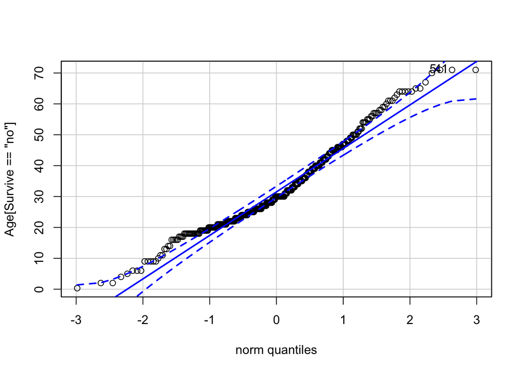

```
## [1]  5 41
```

```r
# Q-Q plot separated by group (surviving, yes or no). CHANGE THE VARIABLE NAMES IF NEEDED~!
library(car) # load the package before you use it

# Visualize

# HINT: with(DATASET, qqPlot(RESPONSEVARIABLE[GROUPVARIABLE == "no"],))
with(titanic, qqPlot(Age[Survive == "no"],)) # did you name titanic.csv "titanic"? if not, change it here
```

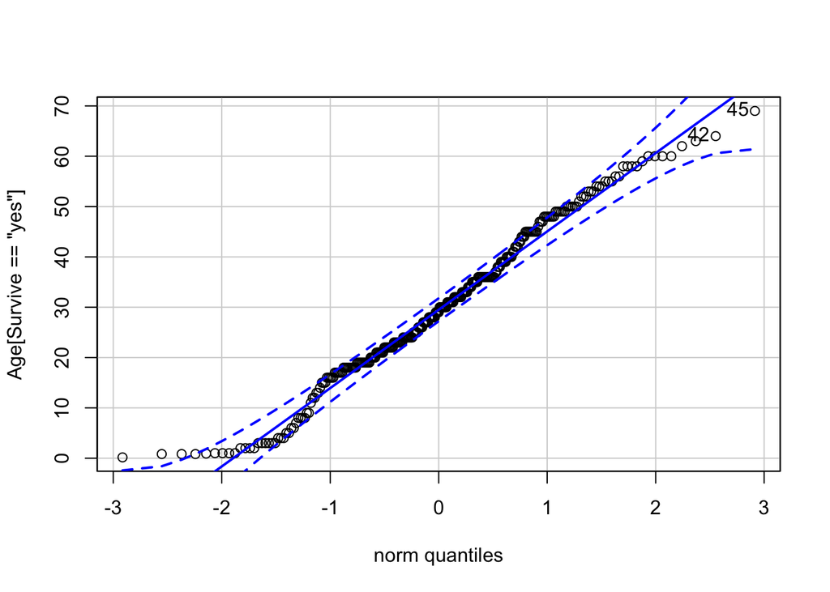

```
## [1] 45 42
```

```r
with(titanic, qqPlot(Age[Survive == "yes"],)) # did you name titanic.csv "titanic"? if not, change it here
```

```r
# Quantify
# Shapiro-Wilk test
with(titanic, shapiro.test(Age[Survive == "yes"]))
```

```
##
##  Shapiro-Wilk normality test
##
## data:  Age[Survive == "yes"]
## W = 0.98271, p-value = 0.001775
```

```r
with(titanic, shapiro.test(Age[Survive == "no"]))
```

```
##
##  Shapiro-Wilk normality test
##
## data:  Age[Survive == "no"]
## W = 0.96477, p-value = 1.667e-07
```

Check if each group has the same variance:

```r
# Levene's test: response variable, group variable
leveneTest(titanic$Age, titanic$Survive)
```

```
## Levene's Test for Homogeneity of Variance (center = median)
##        Df F value  Pr(>F)
## group   1  5.1144 0.02407 *
##       631
## ---
## Signif. codes:  0 '***' 0.001 '**' 0.01 '*' 0.05 '.' 0.1 ' ' 1
```

Notice that $p=0.02407$. We therefore reject our null hypothesis that the variances are equal.

3. Specify $H_0 : \mu_{survive} = \mu_{casualty}$ OR $H_0 : \mu_{survive} - \mu_{casualty} = 0$ and $H_A : \mu_{survive} \neq \mu_{casualty}$ OR $H_A : \mu_{survive} - \mu_{casualty} \neq 0$
4. Use R to perform a two-sample t-test with unequal variances:

```r
# two-sample t-test with unequal variances (Welch's two-sample t-test)

#first, you have to subset the two groups
lived <- subset(titanic, Survive=="yes")
died <- subset(titanic, Survive=="no")

#now, run the t-test on those groups
t.test(lived$Age, died$Age, var.equal = FALSE) # note that 95% CI and a two-sided hypothesis are default settings, meaning we don't have to set them here!
```

```
##
##  Welch Two Sample t-test
##
## data:  lived$Age and died$Age
## t = -1.9947, df = 570.96, p-value = 0.04655
## alternative hypothesis: true difference in means is not equal to 0
## 95 percent confidence interval:
##  -4.71184176 -0.03644633
## sample estimates:
## mean of x mean of y
##  29.87396  32.24811
```

Based on the output above, we see that $p=0.04655$ is less than $p=0.05$ and our 95% CI does not contain 0. Therefore, we can reject our null hypothesis and say that there is in fact a significant difference between the means.  
If we want to test, say, that the mean age of the survivors is significantly *less* than the mean age of the casualties, we could run a one-sided test:

```r
t.test(lived$Age, died$Age, alternative="less", var.equal = FALSE) # here, we specify the one-sided "less" hypothesis, since two-sided is the default setting and we want to override that.
```

```
##
##  Welch Two Sample t-test
##
## data:  lived$Age and died$Age
## t = -1.9947, df = 570.96, p-value = 0.02327
## alternative hypothesis: true difference in means is less than 0
## 95 percent confidence interval:
##        -Inf -0.4132635
## sample estimates:
## mean of x mean of y
##  29.87396  32.24811
```

Now, we find that there is a statistical difference in the age of survivors - *the survivors were statistically younger than those that died*.

# HOMEWORK

All homework questions are due next Wednesday before noon. Use R Markdown to turn in all your exercises and upload the necessary code and answers either an an HTML or PDF file to Gauchospace. Answers must be in complete sentences and quantitative numbers supporting your qualitative assessment need to be reported. For all exercises, alpha = 0.05.

**Question 1: Dominant hand vs/ weak hand dexterity**

1. Clearly *state* your null and alternative hypotheses of your paired t-test.
2. Visualize your data in a meaningful way.
3. Determine if the data are normally distributed and, if not, whether you think the Central Limit Theorem will allow you to use a statistical test that assumes normality. Include both a qqPlot and a Shapiro-Wilk statistic.
   - Hint: to do this you will need to create a new variable that is the difference between each person’s weak hand and dominant hand and test whether this new variable is normally distributed using a qqPlot and a Shapiro-Wilk test.
4. Regardless of whether or not you think the assumptions of the t-test hold, *report* the 95% confidence interval for the paired t-test. Use the 95% CI to reject or fail to reject your null hypothesis. Be specific as to why you do one or the other and *state* your conclusions about the dominant v. weak hand dexterity.

**Question 2: Natural selection in birds**

In 1898, Hermon Bumpus collected data on one of the first examples of natural selection directly observed in nature. Immediately following a bad winter storm, 136 English house sparrows were collected and brought indoors. Of these, 72 subsequently recovered, but 64 died :(. Bumpus made several measurements on all of the birds, and he was able to demonstrate strong natural selection on some of the traits as a result of this storm!  
Bumpus published all of his data, and you can find them in the file *bumpus.csv*. Test whether the birds that *survived or died* (survival) differeed in *total length* (total_length_mm). Specifically, include the following in your homework, along with all necessary code:

1. Clearly *state* your null and alternative hypotheses of your **two-sample t-test**.
2. Visualize your data in some meaningful way, and *explain* what information you get from the visualization. Include this plot in your report.
3. Check whether the normality assumption is valid for the two-sample t-test using the procedure described earlier. Include the Shapiro-Wilk p-value and the qqPlot and *explain* whether or not the normality assumption is valid.
4. Test whether the trait has equal variance between dead and alive birds using a Levene’s Test. *Report* the results of your Levene’s test. Based on the results, *state* whether the groups have equal or unequal variances.
5. Perform the appropriate two-sample t-test and display your results. Clearly *state* your conclusion from the two-sample t-test in terms of how the trait affects a bird’s survival during winter storms.